# Cleaning Data in R

GT

November 8, 2016

### Introduction and exploring raw data

This chapter will give you an overview of the process of data cleaning with R, then walk you through the basics of exploring raw data.

#### The data cleaning process

1. Exploring raw data
2. Tidying data
3. Preparing data for analysis
4. Putting it all together

No one likes missing data, but it is dangerous to assume that it can simply be removed or replaced. Sometimes missing data tells us something important about whatever it is that we’re measuring (i.e. The value of the variable that is missing may be related to the reason it is missing). Such data is called Missing not at Random, or MNAR.

#### Here’s what messy data look like

In the final chapter of this course, you will be presented with a messy, real-world dataset containing an entire year’s worth of weather data from Boston, USA. Among other things, you’ll be presented with variables that contain column names, column names that should be values, numbers coded as character strings, and values that are missing, extreme, and downright erroneous!

```r
# View the first 6 rows of data
head(weather)

# View the last 6 rows of data
tail(weather)

# View a condensed summary of the data
str(weather)
```

```
> # View the first 6 rows of data
> head(weather)
  X year month           measure X1 X2 X3 X4 X5 X6 X7 X8 X9 X10 X11 X12 X13 X14
1 1 2014    12  Max.TemperatureF 64 42 51 43 42 45 38 29 49  48  39  39  42  45
2 2 2014    12 Mean.TemperatureF 52 38 44 37 34 42 30 24 39  43  36  35  37  39
3 3 2014    12  Min.TemperatureF 39 33 37 30 26 38 21 18 29  38  32  31  32  33
4 4 2014    12    Max.Dew.PointF 46 40 49 24 37 45 36 28 49  45  37  28  28  29
5 5 2014    12    MeanDew.PointF 40 27 42 21 25 40 20 16 41  39  31  27  26  27
6 6 2014    12     Min.DewpointF 26 17 24 13 12 36 -3  3 28  37  27  25  24  25
  X15 X16 X17 X18 X19 X20 X21 X22 X23 X24 X25 X26 X27 X28 X29 X30 X31
1  42  44  49  44  37  36  36  44  47  46  59  50  52  52  41  30  30
2  37  40  45  40  33  32  33  39  45  44  52  44  45  46  36  26  25
3  32  35  41  36  29  27  30  33  42  41  44  37  38  40  30  22  20
4  33  42  46  34  25  30  30  39  45  46  58  31  34  42  26  10   8
5  29  36  41  30  22  24  27  34  42  44  43  29  31  35  20   4   5
```

[output cut: 65 more lines]

You may have already noticed messy aspects of the dataset. If not, don’t worry! We’ll get to that soon.

#### Here’s what clean data look like

In this course, you will acquire many new tools in your data cleaning toolbox for whipping the weather data into shape!

```r
# View the first 6 rows of data
head(weather_clean)

# View the last 6 rows of data
tail(weather_clean)

# View a condensed summary of the data
str(weather_clean)
```

```
> # View the first 6 rows of data
> head(weather_clean)
        date    events cloud_cover max_dew_point_f max_gust_speed_mph
1 2014-12-01      Rain           6              46                 29
2 2014-12-02 Rain-Snow           7              40                 29
3 2014-12-03      Rain           8              49                 38
4 2014-12-04      None           3              24                 33
5 2014-12-05      Rain           5              37                 26
6 2014-12-06      Rain           8              45                 25
  max_humidity max_sea_level_pressure_in max_temperature_f max_visibility_miles
1           74                     30.45                64                   10
2           92                     30.71                42                   10
3          100                     30.40                51                   10
4           69                     30.56                43                   10
5           85                     30.68                42                   10
```

[output cut: 109 more lines]

Doesn’t this dataset already look nicer than in the previous exercise?

#### Getting a feel for your data

The first thing to do when you get your hands on a new dataset is to understand its structure. There are several ways to go about this in R, each of which may reveal different issues with your data that require attention.

In this course, we are only concerned with data that can be expressed in table format (i.e. two dimensions, rows and columns). As you may recall from earlier courses, tables in R often have the type `data.frame`. You can check the `class` of any object in R with the `class()` function.

Once you know that you are dealing with tabular data, you may also wanto to get a quick feel for the contents of your data. Before printing the entire dataset to the console, it’s probabily worth knowing how many rows and columns there are. The `dim()` command tells you this.

Loaded a dataset called bmi into your workspace. The data, which give the (age standardized) mean body mass index (BMI) among males in each country for the years 1980-2008

```r
# Load bmi.csv
bmi <- read.csv("bmi.csv")

# Check the class of bmi
class(bmi)
```

```
## [1] "data.frame"
```

```r
# Check the dimensions of bmi
dim(bmi)
```

```
## [1] 199  30
```

```r
# View the column names of bmi
names(bmi)
```

```
##  [1] "Country" "Y1980"   "Y1981"   "Y1982"   "Y1983"   "Y1984"   "Y1985"
##  [8] "Y1986"   "Y1987"   "Y1988"   "Y1989"   "Y1990"   "Y1991"   "Y1992"
## [15] "Y1993"   "Y1994"   "Y1995"   "Y1996"   "Y1997"   "Y1998"   "Y1999"
## [22] "Y2000"   "Y2001"   "Y2002"   "Y2003"   "Y2004"   "Y2005"   "Y2006"
## [29] "Y2007"   "Y2008"
```

#### Viewing the structure of your data

Since `bmi` doesn’t have a huge number of columns, you can view a quick snapshot of your data using `str()` command. In addition to the class and dimensions of your *entire dataset*, `str()` will tell you the class of *each variable* and give you a preview of its contents.

Although we won’t go into detail on the `dplyr` package in this lesson, the `glimpse()` function from `dplyr` is a slightly cleaner alternative to `str()`. `str()` and `glimpse()` give you a preview of your data, which may reveal issues with the way columns are labelled, how variables are encoded, etc.

You can use the `summary()` command to get a better feel for how your data are distributed, which may reveal unusual or extreme values, unexpected missing data, etc. For numeric variables, this means looking at means, quartiles (including median), and extreme values. For character or factor variables, you may be curious about the number of times each value appears in the data (i.e. counts).

```r
# Check the structure of bmi
str(bmi)
```

```
## 'data.frame':    199 obs. of  30 variables:
##  $ Country: Factor w/ 199 levels "Afghanistan",..: 1 2 3 4 5 6 7 8 9 10 ...
##  $ Y1980  : num  21.5 25.2 22.3 25.7 20.9 ...
##  $ Y1981  : num  21.5 25.2 22.3 25.7 20.9 ...
##  $ Y1982  : num  21.5 25.3 22.4 25.7 20.9 ...
##  $ Y1983  : num  21.4 25.3 22.5 25.8 20.9 ...
##  $ Y1984  : num  21.4 25.3 22.6 25.8 20.9 ...
##  $ Y1985  : num  21.4 25.3 22.7 25.9 20.9 ...
##  $ Y1986  : num  21.4 25.3 22.8 25.9 21 ...
##  $ Y1987  : num  21.4 25.3 22.8 25.9 21 ...
##  $ Y1988  : num  21.3 25.3 22.9 26 21 ...
##  $ Y1989  : num  21.3 25.3 23 26 21.1 ...
##  $ Y1990  : num  21.2 25.3 23 26.1 21.1 ...
##  $ Y1991  : num  21.2 25.3 23.1 26.2 21.1 ...
##  $ Y1992  : num  21.1 25.2 23.2 26.2 21.1 ...
```

[output cut: 16 more lines]

```r
# Load dplyr
library(dplyr)
# Check the structure of bmi, the dplyr way
glimpse(bmi)
```

```
## Observations: 199
## Variables: 30
## $ Country <fctr> Afghanistan, Albania, Algeria, Andorra, Angola, Antig...
## $ Y1980   <dbl> 21.48678, 25.22533, 22.25703, 25.66652, 20.94876, 23.3...
## $ Y1981   <dbl> 21.46552, 25.23981, 22.34745, 25.70868, 20.94371, 23.3...
## $ Y1982   <dbl> 21.45145, 25.25636, 22.43647, 25.74681, 20.93754, 23.4...
## $ Y1983   <dbl> 21.43822, 25.27176, 22.52105, 25.78250, 20.93187, 23.5...
## $ Y1984   <dbl> 21.42734, 25.27901, 22.60633, 25.81874, 20.93569, 23.6...
## $ Y1985   <dbl> 21.41222, 25.28669, 22.69501, 25.85236, 20.94857, 23.7...
## $ Y1986   <dbl> 21.40132, 25.29451, 22.76979, 25.89089, 20.96030, 23.8...
## $ Y1987   <dbl> 21.37679, 25.30217, 22.84096, 25.93414, 20.98025, 23.9...
## $ Y1988   <dbl> 21.34018, 25.30450, 22.90644, 25.98477, 21.01375, 24.0...
## $ Y1989   <dbl> 21.29845, 25.31944, 22.97931, 26.04450, 21.05269, 24.1...
## $ Y1990   <dbl> 21.24818, 25.32357, 23.04600, 26.10936, 21.09007, 24.2...
## $ Y1991   <dbl> 21.20269, 25.28452, 23.11333, 26.17912, 21.12136, 24.3...
```

[output cut: 17 more lines]

```r
# View a summary of bmi
summary(bmi)
```

```
##                 Country        Y1980           Y1981           Y1982
##  Afghanistan        :  1   Min.   :19.01   Min.   :19.04   Min.   :19.07
##  Albania            :  1   1st Qu.:21.27   1st Qu.:21.31   1st Qu.:21.36
##  Algeria            :  1   Median :23.31   Median :23.39   Median :23.46
##  Andorra            :  1   Mean   :23.15   Mean   :23.21   Mean   :23.26
##  Angola             :  1   3rd Qu.:24.82   3rd Qu.:24.89   3rd Qu.:24.94
##  Antigua and Barbuda:  1   Max.   :28.12   Max.   :28.36   Max.   :28.58
##  (Other)            :193
##      Y1983           Y1984           Y1985           Y1986
##  Min.   :19.10   Min.   :19.13   Min.   :19.16   Min.   :19.20
##  1st Qu.:21.42   1st Qu.:21.45   1st Qu.:21.47   1st Qu.:21.49
##  Median :23.57   Median :23.64   Median :23.73   Median :23.82
##  Mean   :23.32   Mean   :23.37   Mean   :23.42   Mean   :23.48
##  3rd Qu.:25.02   3rd Qu.:25.06   3rd Qu.:25.11   3rd Qu.:25.20
##  Max.   :28.82   Max.   :29.05   Max.   :29.28   Max.   :29.52
##
##      Y1987           Y1988           Y1989           Y1990
##  Min.   :19.23   Min.   :19.27   Min.   :19.31   Min.   :19.35
##  1st Qu.:21.50   1st Qu.:21.52   1st Qu.:21.55   1st Qu.:21.57
##  Median :23.87   Median :23.93   Median :24.03   Median :24.14
##  Mean   :23.53   Mean   :23.59   Mean   :23.65   Mean   :23.71
##  3rd Qu.:25.27   3rd Qu.:25.34   3rd Qu.:25.37   3rd Qu.:25.39
##  Max.   :29.75   Max.   :29.98   Max.   :30.20   Max.   :30.42
##
##      Y1991           Y1992           Y1993           Y1994
##  Min.   :19.40   Min.   :19.45   Min.   :19.51   Min.   :19.59
##  1st Qu.:21.60   1st Qu.:21.65   1st Qu.:21.74   1st Qu.:21.76
##  Median :24.20   Median :24.19   Median :24.27   Median :24.36
##  Mean   :23.76   Mean   :23.82   Mean   :23.88   Mean   :23.94
##  3rd Qu.:25.42   3rd Qu.:25.48   3rd Qu.:25.54   3rd Qu.:25.62
##  Max.   :30.64   Max.   :30.85   Max.   :31.04   Max.   :31.23
##
##      Y1995           Y1996           Y1997           Y1998
##  Min.   :19.67   Min.   :19.71   Min.   :19.74   Min.   :19.77
##  1st Qu.:21.83   1st Qu.:21.89   1st Qu.:21.94   1st Qu.:22.00
##  Median :24.41   Median :24.42   Median :24.50   Median :24.49
##  Mean   :24.00   Mean   :24.07   Mean   :24.14   Mean   :24.21
##  3rd Qu.:25.70   3rd Qu.:25.78   3rd Qu.:25.85   3rd Qu.:25.94
##  Max.   :31.41   Max.   :31.59   Max.   :31.77   Max.   :31.95
##
```

[output cut: 9 more lines]

```
##  Min.   :19.81   Min.   :19.79   Min.   :19.79   Min.   :19.80
##  1st Qu.:22.37   1st Qu.:22.45   1st Qu.:22.54   1st Qu.:22.63
##  Median :24.89   Median :25.00   Median :25.11   Median :25.24
##  Mean   :24.61   Mean   :24.70   Mean   :24.79   Mean   :24.89
##  3rd Qu.:26.38   3rd Qu.:26.47   3rd Qu.:26.53   3rd Qu.:26.59
##  Max.   :32.90   Max.   :33.10   Max.   :33.30   Max.   :33.49
##
##      Y2007           Y2008
##  Min.   :19.83   Min.   :19.87
##  1st Qu.:22.73   1st Qu.:22.83
##  Median :25.36   Median :25.50
##  Mean   :24.99   Mean   :25.10
##  3rd Qu.:26.66   3rd Qu.:26.82
##  Max.   :33.69   Max.   :33.90
##
```

#### Looking at your data

You can look at all the summaries you want, but at the end of the day, there is no substitute for looking at your data, either in raw table form or by plotting it.

The most basic way to look at your data in R is by printing it to the console. As you may know from experience, the `print()` command is not even necessary; you can just type the name of the object. The downside to this option is that R will attempt to print the entire dataset, which can be a nuisance if the dataset is too large.

One way around this is to use the `head()` and `tail()` commands, which only display the first and last 6 rows of data, respectively. You can view more (or fewer) rows by providing as a second argument to the function the number of rows you wish to view. These functions provide a useful method for quickly getting a sense of your data without overly cluttering the console.

```r
# View the first 6 rows
head(bmi)
```

```
##               Country    Y1980    Y1981    Y1982    Y1983    Y1984
## 1         Afghanistan 21.48678 21.46552 21.45145 21.43822 21.42734
## 2             Albania 25.22533 25.23981 25.25636 25.27176 25.27901
## 3             Algeria 22.25703 22.34745 22.43647 22.52105 22.60633
## 4             Andorra 25.66652 25.70868 25.74681 25.78250 25.81874
## 5              Angola 20.94876 20.94371 20.93754 20.93187 20.93569
## 6 Antigua and Barbuda 23.31424 23.39054 23.45883 23.53735 23.63584
##      Y1985    Y1986    Y1987    Y1988    Y1989    Y1990    Y1991    Y1992
## 1 21.41222 21.40132 21.37679 21.34018 21.29845 21.24818 21.20269 21.14238
## 2 25.28669 25.29451 25.30217 25.30450 25.31944 25.32357 25.28452 25.23077
## 3 22.69501 22.76979 22.84096 22.90644 22.97931 23.04600 23.11333 23.18776
## 4 25.85236 25.89089 25.93414 25.98477 26.04450 26.10936 26.17912 26.24017
## 5 20.94857 20.96030 20.98025 21.01375 21.05269 21.09007 21.12136 21.14987
## 6 23.73109 23.83449 23.93649 24.05364 24.16347 24.26782 24.36568 24.45644
##      Y1993    Y1994    Y1995    Y1996    Y1997    Y1998    Y1999    Y2000
## 1 21.06376 20.97987 20.91132 20.85155 20.81307 20.78591 20.75469 20.69521
## 2 25.21192 25.22115 25.25874 25.31097 25.33988 25.39116 25.46555 25.55835
## 3 23.25764 23.32273 23.39526 23.46811 23.54160 23.61592 23.69486 23.77659
## 4 26.30356 26.36793 26.43569 26.50769 26.58255 26.66337 26.75078 26.83179
## 5 21.13938 21.14186 21.16022 21.19076 21.22621 21.27082 21.31954 21.37480
## 6 24.54096 24.60945 24.66461 24.72544 24.78714 24.84936 24.91721 24.99158
##      Y2001    Y2002    Y2003    Y2004    Y2005    Y2006    Y2007    Y2008
## 1 20.62643 20.59848 20.58706 20.57759 20.58084 20.58749 20.60246 20.62058
## 2 25.66701 25.77167 25.87274 25.98136 26.08939 26.20867 26.32753 26.44657
## 3 23.86256 23.95294 24.05243 24.15957 24.27001 24.38270 24.48846 24.59620
## 4 26.92373 27.02525 27.12481 27.23107 27.32827 27.43588 27.53363 27.63048
## 5 21.43664 21.51765 21.59924 21.69218 21.80564 21.93881 22.08962 22.25083
## 6 25.05857 25.13039 25.20713 25.29898 25.39965 25.51382 25.64247 25.76602
```

```r
# View the first 15 rows
head(bmi, n=15)
```

```
##                Country    Y1980    Y1981    Y1982    Y1983    Y1984
## 1          Afghanistan 21.48678 21.46552 21.45145 21.43822 21.42734
## 2              Albania 25.22533 25.23981 25.25636 25.27176 25.27901
## 3              Algeria 22.25703 22.34745 22.43647 22.52105 22.60633
## 4              Andorra 25.66652 25.70868 25.74681 25.78250 25.81874
## 5               Angola 20.94876 20.94371 20.93754 20.93187 20.93569
## 6  Antigua and Barbuda 23.31424 23.39054 23.45883 23.53735 23.63584
## 7            Argentina 25.37913 25.44951 25.50242 25.55644 25.61271
## 8              Armenia 23.82469 23.86401 23.91023 23.95649 24.00181
## 9            Australia 24.92729 25.00216 25.07660 25.14938 25.22894
## 10             Austria 24.84097 24.88110 24.93482 24.98118 25.02208
## 11          Azerbaijan 24.49375 24.52584 24.56064 24.60150 24.64121
## 12             Bahamas 24.21064 24.30814 24.42750 24.54415 24.66558
## 13             Bahrain 23.97588 24.09045 24.20617 24.32335 24.43174
## 14          Bangladesh 20.51918 20.47766 20.43741 20.40075 20.36524
```

[output cut: 49 more lines]

```r
# View the last 6 rows
tail(bmi)
```

```
##                            Country    Y1980    Y1981    Y1982    Y1983
## 194                        Vanuatu 23.20701 23.32990 23.46016 23.60431
## 195 Venezuela (Bolivarian Republic 24.58052 24.69666 24.80082 24.89208
## 196                       Viet Nam 19.01394 19.03902 19.06804 19.09675
## 197                          Yemen 22.90384 22.96813 23.02669 23.07279
## 198                         Zambia 19.66295 19.69512 19.72538 19.75420
## 199                       Zimbabwe 21.46989 21.48867 21.50738 21.52936
##        Y1984    Y1985    Y1986    Y1987    Y1988    Y1989    Y1990
## 194 23.75134 23.89466 24.03171 24.15571 24.27529 24.39727 24.52964
## 195 24.98440 25.07104 25.15587 25.24624 25.35274 25.43322 25.52678
## 196 19.13046 19.16397 19.19740 19.23481 19.27090 19.31105 19.35150
## 197 23.12566 23.16944 23.20933 23.25043 23.29401 23.33879 23.38236
## 198 19.78070 19.80335 19.82396 19.85065 19.88320 19.92451 19.96680
## 199 21.53383 21.54341 21.54859 21.54590 21.55396 21.56903 21.58005
##        Y1991    Y1992    Y1993    Y1994    Y1995    Y1996    Y1997
```

[output cut: 20 more lines]

```r
# View the last 10 rows
tail(bmi, n=10)
```

```
##                            Country    Y1980    Y1981    Y1982    Y1983
## 190    United Republic of Tanzania 21.27393 21.30234 21.33163 21.36444
## 191       United States of America 25.46406 25.57524 25.67883 25.78812
## 192                        Uruguay 24.24001 24.31948 24.39260 24.44209
## 193                     Uzbekistan 24.56500 24.60077 24.62187 24.64780
## 194                        Vanuatu 23.20701 23.32990 23.46016 23.60431
## 195 Venezuela (Bolivarian Republic 24.58052 24.69666 24.80082 24.89208
## 196                       Viet Nam 19.01394 19.03902 19.06804 19.09675
## 197                          Yemen 22.90384 22.96813 23.02669 23.07279
## 198                         Zambia 19.66295 19.69512 19.72538 19.75420
## 199                       Zimbabwe 21.46989 21.48867 21.50738 21.52936
##        Y1984    Y1985    Y1986    Y1987    Y1988    Y1989    Y1990
## 190 21.39463 21.41743 21.43652 21.45773 21.48072 21.50454 21.53365
## 191 25.90690 26.02568 26.13740 26.25939 26.37687 26.49269 26.60827
## 192 24.49525 24.54516 24.59804 24.67024 24.73972 24.80593 24.86952
```

[output cut: 40 more lines]

#### Visualizing your data

There are many ways to visualize data. Since this is not a course about data visualization, we will only touch on two types of plots that may be useful for quickly identifying extreme or suspicious values in your data: histograms and scatter plots.

A histogram, created with the `hist()` function, takes a vector (i.e. column) of data, breaks it up to intervals, then plots as a vertical bar the number of instances within each interval.

A scatter plot, created with the `plot()` function, takes two vectors of data and plots them as a series of `(x, y)` coordinates on a two-dimensional plane.

`r # Histogram of BMIs from 2008 hist(bmi$Y2008)`

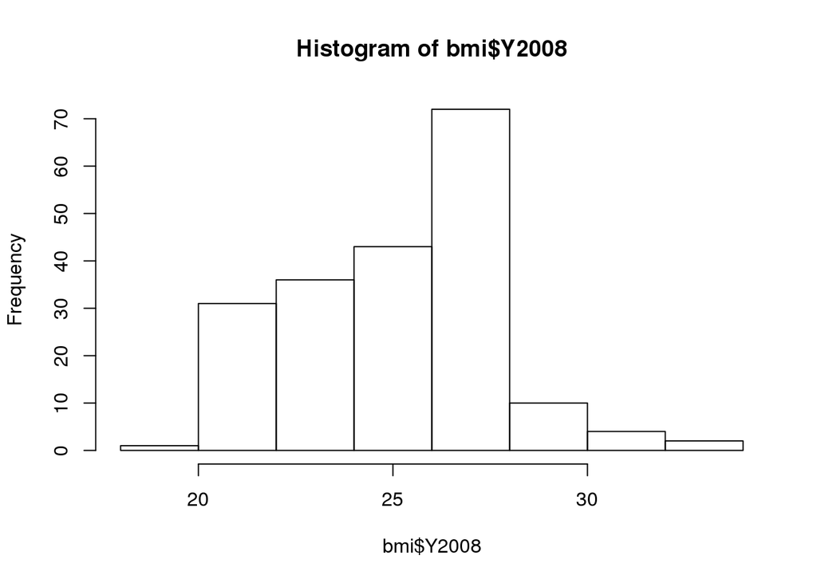

`r # Scatter plot comparing BMIs from 1980 to those from 2008 plot(bmi$Y1980, bmi$Y2008)`

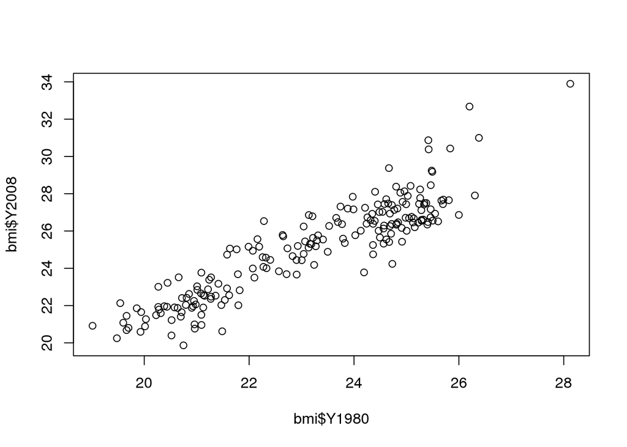

### Tidying data

#### Principles of tidy data

- Observation as rows
- Variables as columns
- One type of observational unit per table

#### Common symptoms of messy data

Multiple variables stored in one column is messy, but there should be multiple values in each column.

#### What kind of messy are the BMI data?

Which symptom of messy data is exhibited by `bmi` ?

Column headers are values, not variable names. All of the year column names could be expressed as values of a new variable called `year`.

#### Gathering columns Into key-value pairs

The most important function in `tidyr` is `gather()`. It should be used when you have columns that are not varibles and you want to collapse them into key-value pairs.

The easiest way to visualize the effect of `gather()` is that it makes wide datasets long. As you saw in the video, running the following command on `wide_df` will make it long:

```
gather(wide_df, my_key, my_val, -col)
```

```r
# Load dplyr
library(tidyr)

# Apply gather() to bmi and save the result as bmi_long
bmi_long <- gather(bmi, year, bmi_val, -Country)

# View the first 20 rows of the result
head(bmi_long, n = 20)
```

```
##                Country  year  bmi_val
## 1          Afghanistan Y1980 21.48678
## 2              Albania Y1980 25.22533
## 3              Algeria Y1980 22.25703
## 4              Andorra Y1980 25.66652
## 5               Angola Y1980 20.94876
## 6  Antigua and Barbuda Y1980 23.31424
## 7            Argentina Y1980 25.37913
## 8              Armenia Y1980 23.82469
## 9            Australia Y1980 24.92729
## 10             Austria Y1980 24.84097
## 11          Azerbaijan Y1980 24.49375
## 12             Bahamas Y1980 24.21064
## 13             Bahrain Y1980 23.97588
## 14          Bangladesh Y1980 20.51918
## 15            Barbados Y1980 24.36372
## 16             Belarus Y1980 24.90898
## 17             Belgium Y1980 25.09879
## 18              Belize Y1980 24.54345
## 19               Benin Y1980 20.80754
## 20             Bermuda Y1980 25.07881
```

Notice how now, instead of being represented in the column names, years are now all neatly represented in the `year` column. Try checking `dim(bmi_long)` and `dim(bmi)` before moving on.

```r
dim(bmi_long)
```

```
## [1] 5771    3
```

```r
dim(bmi)
```

```
## [1] 199  30
```

#### Spreading key-value pairs into columns

The opposite of `gather()` is `spread()`, which takes key-values pairs and spreads theme across multiple columns. This is useful when values in a column should actually be column names (i.e. variables). It can also make data more compact and easier to read.

The easiest way to visualize the effect of `spread()` is that it makes long datasets wide. As you saw in the video, running the following command will make `long_df` wide:

```
spread(long_df, my_key, my_val)
```

```r
# Apply spread() to bmi_long
bmi_wide <- spread(bmi_long, year, bmi_val)

# View the head of bmi_wide
head(bmi_wide)
```

```
##               Country    Y1980    Y1981    Y1982    Y1983    Y1984
## 1         Afghanistan 21.48678 21.46552 21.45145 21.43822 21.42734
## 2             Albania 25.22533 25.23981 25.25636 25.27176 25.27901
## 3             Algeria 22.25703 22.34745 22.43647 22.52105 22.60633
## 4             Andorra 25.66652 25.70868 25.74681 25.78250 25.81874
## 5              Angola 20.94876 20.94371 20.93754 20.93187 20.93569
## 6 Antigua and Barbuda 23.31424 23.39054 23.45883 23.53735 23.63584
##      Y1985    Y1986    Y1987    Y1988    Y1989    Y1990    Y1991    Y1992
## 1 21.41222 21.40132 21.37679 21.34018 21.29845 21.24818 21.20269 21.14238
## 2 25.28669 25.29451 25.30217 25.30450 25.31944 25.32357 25.28452 25.23077
## 3 22.69501 22.76979 22.84096 22.90644 22.97931 23.04600 23.11333 23.18776
## 4 25.85236 25.89089 25.93414 25.98477 26.04450 26.10936 26.17912 26.24017
## 5 20.94857 20.96030 20.98025 21.01375 21.05269 21.09007 21.12136 21.14987
## 6 23.73109 23.83449 23.93649 24.05364 24.16347 24.26782 24.36568 24.45644
##      Y1993    Y1994    Y1995    Y1996    Y1997    Y1998    Y1999    Y2000
## 1 21.06376 20.97987 20.91132 20.85155 20.81307 20.78591 20.75469 20.69521
## 2 25.21192 25.22115 25.25874 25.31097 25.33988 25.39116 25.46555 25.55835
## 3 23.25764 23.32273 23.39526 23.46811 23.54160 23.61592 23.69486 23.77659
## 4 26.30356 26.36793 26.43569 26.50769 26.58255 26.66337 26.75078 26.83179
## 5 21.13938 21.14186 21.16022 21.19076 21.22621 21.27082 21.31954 21.37480
## 6 24.54096 24.60945 24.66461 24.72544 24.78714 24.84936 24.91721 24.99158
##      Y2001    Y2002    Y2003    Y2004    Y2005    Y2006    Y2007    Y2008
## 1 20.62643 20.59848 20.58706 20.57759 20.58084 20.58749 20.60246 20.62058
## 2 25.66701 25.77167 25.87274 25.98136 26.08939 26.20867 26.32753 26.44657
## 3 23.86256 23.95294 24.05243 24.15957 24.27001 24.38270 24.48846 24.59620
## 4 26.92373 27.02525 27.12481 27.23107 27.32827 27.43588 27.53363 27.63048
## 5 21.43664 21.51765 21.59924 21.69218 21.80564 21.93881 22.08962 22.25083
## 6 25.05857 25.13039 25.20713 25.29898 25.39965 25.51382 25.64247 25.76602
```

```r
# Check dimension of bmi_wide and bmi
dim(bmi_wide)
```

```
## [1] 199  30
```

```r
dim(bmi)
```

```
## [1] 199  30
```

#### Function in tidyr

- `gather()` - Gather columns into key-value pairs
- `spread()` - Spread key-value pairs into columns
- `separate()` - Separate one column into multiple
- `unite()` - Unite multiple columns into one

#### Separating columns

The `separate()` function allows you to separate one column into multiple columms. Unless you tell it otherwise, it will attempt to separate on any character that is not a letter or number. You can also specify a specific separator using the `sep` argument.

For exammple we have a dataset called `treatments`. This dataset obeys the principle of tidy data, but we’d like to split the treatment dates onto two separate columns: `year` and `month`. This can be accomplished with the following:

```
separate(tratments, years_mo, c("year", "month"))
```

For the dataset called `bmi_cc`, the `Country_ISO` column has the name of each country as well its two-letter ISO country code, separated by a forward slash.

```r
# Apply separate() to bmi_cc
bmi_cc_clean <- separate(bmi_cc, col = Country_ISO, into = c("Country", "ISO"), sep = "/")

# Print the head of the result
head(bmi_cc_clean)
```

It’s good to be familiar with the separate function. In practice, it’s often used to break date-time values into their individual pieces (day, month, year, etc.)

#### Uniting columns

The opposite of `separate()` is `unite()`, which takes multiple columns and pastes them together. By default, the contents of the columns will be separated by underscores in the new column, but this behavior can be altered via the `sep` argument.

This time the `year_mo` column has been separated into `year` and `month`. The original column can be recreated by putting `year` and `month` back together:

```
unite(treatments, year_mo, year, month)
```

As previously, put the columns `Country` and `ISO` together.

```r
# Apply unite() to bmi_cc_clean
bmi_cc <- unite(bmi_cc_clean, Country_ISO, Country, ISO, sep = "-")

# View the head of the result
head(bmi_cc)
```

#### Column headers are values, not variable names

You saw earlier in the chapter how we sometimes come across datasets where column names are actually values of a variable (e.g. months of the year). This is often the case when working with repeated measures data, where measurements are taken on subjects of intererst on multiple occasions over time. The `gather()` function is helpful in these situations.

```r
## tidyr and dplyr are already loaded for you

# View the head of census
head(census)

# Gather the month columns
census2 <- gather(census, month, amount, -YEAR)

# Arrange rows by YEAR using dplyr's arrange
census2 <- arrange(census2, YEAR)

# View first 20 rows of census2
head(census2, n = 20)
```

Many datasets dealing with historical data appear in this format with time expressed horizontally. Understanding how to tidy these data is key for efficient data analysis.

#### Variables are stored in both rows and columns

Sometimes you’ll run into situations where varibles are stored in both rows and columns. To illustrate this, we’ve loaded the `pets` dataset from the video, which tell us in a convoluted way how many birds, cats and dogs, Jason, Lisa and Terrence have.

```
> pets

     owner type num
1    Jason  dog   2
2    Jason  cat   4
3    Jason bird   3
4     Lisa  dog   7
5     Lisa  cat  10
6     Lisa bird   9
7 Terrence  dog   8
8 Terrence  cat   5
9 Terrence bird   1
```

Altough it may not be immediately obvious,if we treat the values in the `type` column as variables and create a separate column for each of them, we can set things straight. To do this, we use the `spread()` function.

```
> spread(pets, type, num)

     owner bird cat dog
1    Jason    3   4   2
2     Lisa    9  10   7
3 Terrence    1   5   8
```

The result shows the exact same information in a much clearer way! Notice that the `spread()` function took in three arguments. The first argument takes the name of your messy dataset (`pets`), the second argument takes the name of the column to spread into new columns (`type`), and the third argument takes the column that contains the value with which to fill in the newly spread out columns (`num`).

```r
## tidyr is already loaded for you

# View first 50 rows of census_long
head(census_long, n = 50)

# Spread the type column
census_long2 <- spread(census_long, type, amount);

# View first 20 rows of census_long2
head(census_long2, n = 20)
```

#### Multiple values are stored in one column

It’s also fairly common that you will find two variables stored in a sigle column of data. These variables may be joined by a separator like a dash, underscore, space, or forward slash.

The `separate()` function comes in handy in these situations. To practice using it, we have created a slight modification of last exercise’s result. Keep in mind that the `into` argument, which specifies the names of the 2 new columns being formed, must be given as a character vector (e.g. `c("column1", "column2")`).

```r
## tidyr is already loaded for you

# View the head of census_long3
head(census_long3)

# Separate the yr_month column into two
census_long4 <- separate(census_long3, yr_month, c("year", "month"), sep = "_")

# View the first 6 rows of the result
head(census_long4)
```

### Preparing data for analysis

This chapter will teach you how to prepare your data for analysis. We will look at type conversion, string manipulation, missing and special values, and outliers and obvious errors.

#### Types of variables in R

As in other programming languages, R is capable of storing data in many different formats, most of which you’ve probably seen by now.

Loosely speaking, the `class()` function tell you what type of object you’re working with. (There are subtle differences between the `class`, `type` and `mode` of an object, but these distinctions are beyond the scope of this course.)

```r
# Make this evaluate to character
class("true")
```

```
## [1] "character"
```

```r
# Make this evaluate to numeric
class(8484.00)
```

```
## [1] "numeric"
```

```r
# Make this evaluate to integer
class(99L)
```

```
## [1] "integer"
```

```r
# Make this evaluate to factor
class(factor("factor"))
```

```
## [1] "factor"
```

```r
# Make this evaluate to logical
class(FALSE)
```

```
## [1] "logical"
```

#### Common type conversions

It is often necessary to change, or *coerce*, the way that variables in a dataset are stored. This could be because of the way they were read into R (with `read.csv()`, for example) or perhaps the function you are using to analyze the data requires variables to be coded a certain way.

```
as.numeric("some text")

Warning message: NAs introduced by coercion
[1] NA
```

There are a few less intuitive results. For example, under the hood, the logical values `TRUE` and `FALSE` are coded as `1` and `0`, respectively. Therefore, `as.logical(1)` returns `TRUE` and `as.numeric(TRUE)` returns `1`.

```r
# Preview students with str()
str(students)

# Coerce Grades to character
students$Grades <- as.character(students$Grades)

# Coerce Medu to factor
students$Medu <- factor(students$Medu)

# Coerce Fedu to factor
students$Fedu <- factor(students$Fedu)

# Look at students once more with str()
str(students)
```

It’s important to make sure that you know how to change variable types in the event that you get some surprises when you first import your data!

#### Working with dates

Dates can be a challenge to work with in any programming language, but thanks to the `lubridate` package, working with dates in R isn’t so bad. Since this course is about cleaning data, we only cover the most basic functions from `lubridate` to help us standardize the fromat of dates and times on our data.

These functions, combine letters `y`, `m`, `d`, `h`, `m`, `s`, which stand for year, month, day, hour, minute, and second, respectively. The order of the letters in the function should match the order of the date/time you are attempting to read in, although not all combinations are valid. Notice that the functions are “smart” in that they are capable of parsing multiple formats.

```r
# Load the lubridate package
library(lubridate)
# Parse as date
dmy("17 Sep 2015")
```

```
## [1] "2015-09-17"
```

```r
# Parse as date and time (with no seconds!)
mdy_hm("July 15, 2012 12:56")
```

```
## [1] "2012-07-15 12:56:00 UTC"
```

#### Trimming and padding strings

One common issue that comes up when cleaning data is the need to remove leading and/or trailing white space. The `str_trim()` function from `stringr` makes it easy to do this while leaving intact the part of the string that you actually want.

```
> str_trim("   this is a test    ")
[1] "this is a test"
```

A similar issue is when you need to pad strings to make them a certain number of characters wide. One example is if you had a bunch of employee ID numbers, some of which begin with one or more zeros. When reading these data in, you find that the leading zeros have been dropped somewhere along the way (probabily because the variable was thought to be numeric and in that case, leading zeros would be unnecessary).

`> str pad("24493", width = 7, side = "left", pad = "0") [1] "0024493"`

```r
# Load the stringr package
library(stringr)

# Trim all leading and trailing whitespace
str_trim(c("   Filip ", "Nick  ", " Jonathan"))
```

```
## [1] "Filip"    "Nick"     "Jonathan"
```

```r
# Pad these strings with leading zeros
str_pad(c("23485W", "8823453Q", "994Z"), width = 9, side = "left", pad = "0")
```

```
## [1] "00023485W" "08823453Q" "00000994Z"
```

Examples like this are certainly handy in R. For example, the `str_pad()` function is useful when importing a dataset with US zip codes. Occasionally R will drop the leading 0 in a zipcode, thinking it’s numeric. Now that you know how to coerce variable types and pad strings, this won’t set you back!

#### Upper and lower case

In addition to trimming and padding strings, you may need to adjust their case from time to time. Making strings uppercase or lowercase is very straightforward in (base) R thanks to `toupper()` and `tolower()`. Each function takes exactly one argument: the character string (or vector/column of strings) to be converted to the desidered case.

```r
states <- c("al", "ak", "az", "ar", "ca", "co", "ct", "de", "fl",
            "ga", "hi", "id", "il", "in", "ia", "ks", "ky", "la",
            "me", "md", "ma", "mi", "mn", "ms", "mo", "mt", "ne",
            "nv", "nh", "nj", "nm", "ny", "nc", "nd", "oh", "ok",
            "or", "pa", "ri", "sc", "sd", "tn", "tx", "ut", "vt",
            "va", "wa", "wv", "wi", "wy")
# Print state abbreviations
head(states)
```

```
## [1] "al" "ak" "az" "ar" "ca" "co"
```

```r
# Make states all uppercase and save result to states_upper
states_upper <- toupper(states)
head(states_upper)
```

```
## [1] "AL" "AK" "AZ" "AR" "CA" "CO"
```

```r
# Make states_upper all lowercase again
tolower(states_upper)
```

```
##  [1] "al" "ak" "az" "ar" "ca" "co" "ct" "de" "fl" "ga" "hi" "id" "il" "in"
## [15] "ia" "ks" "ky" "la" "me" "md" "ma" "mi" "mn" "ms" "mo" "mt" "ne" "nv"
## [29] "nh" "nj" "nm" "ny" "nc" "nd" "oh" "ok" "or" "pa" "ri" "sc" "sd" "tn"
## [43] "tx" "ut" "vt" "va" "wa" "wv" "wi" "wy"
```

#### Finding and replacing strings

The `stringr` package provides two functions that are very useful for finding and/or replacing strings: `str_detect()` and `str_replace()`.

Like all functions in stringr, the first argument of each is the string of interest. The second argument of each is the pattern of interest. In the aces of `str_detect()`, this is the pattern we are searching for. In the case of `str_replace()`, this is the pattern we want to replace. Finally, `str_replace()` has a third argument, which is the string to replace with.

```r
## stringr has been loaded for you

# Look at the head of students2
head(students2)
```

```
##   X school sex        dob
## 1 1     GB   F 2000-06-05
## 2 2     GB   F 1999-11-25
## 3 3     GB   F 1998-02-02
## 4 4     GB   F 1997-12-20
## 5 5     GB   F 1998-10-04
## 6 6     GB   M 1999-06-16
```

```r
# Detect all dates of birth (dob) in 1997
str_detect(students2$dob, "1997")
```

```
## [1] FALSE FALSE FALSE  TRUE FALSE FALSE
```

```r
# In the sex column, replace "F" with "Female"...
students2$sex <- str_replace(students2$sex, "F", "Female")

# ...And "M" with "Male"
students2$sex <- str_replace(students2$sex, "M", "Male")

# View the head of students2
head(students2)
```

```
##   X school    sex        dob
## 1 1     GB Female 2000-06-05
## 2 2     GB Female 1999-11-25
## 3 3     GB Female 1998-02-02
## 4 4     GB Female 1997-12-20
## 5 5     GB Female 1998-10-04
## 6 6     GB   Male 1999-06-16
```

#### Types of missing and special values in R

Missing values

- In R, represented as `NA`
- May appear in other forms, `#N/A` (Excel), single dot (SPSS, SAS)

Special values

- `Inf` - “Infinite value”
- `NaN` - “Not a number”

#### Finding missing values

As you’ve seen, missing values in R should be represented by `NA`, but unfortunately you will not always be so lucky. Before you can deal with missing values, you have to find them in the data.

If missing value are properly coded as `NA`, the `is.na()` function will help you find them. Otherwise, if your datase is too big to just look at the whole thing, you may need to try searching for some of the usual suspects like `""`, `"#N/A"`, etc. You can also use the `summary()` and `table()` functions to turn up unexpected values in your data.

```r
# Call is.na() on the full social_df to spot all NAs
is.na(social_df)
```

```
##       name n_friends status
## [1,] FALSE     FALSE  FALSE
## [2,] FALSE      TRUE  FALSE
## [3,] FALSE     FALSE  FALSE
## [4,] FALSE     FALSE  FALSE
```

```r
# Use the any() function to ask whether there are any NAs in the data
any(is.na(social_df))
```

```
## [1] TRUE
```

```r
# View a summary() of the dataset
summary(social_df)
```

```
##     name     n_friends                status
##  Alice:1   Min.   : 43.0                 :2
##  David:1   1st Qu.: 94.0   Going out!    :1
##  Sarah:1   Median :145.0   Movie night...:1
##  Tom  :1   Mean   :144.0
##            3rd Qu.:194.5
##            Max.   :244.0
##            NA's   :1
```

```r
# Call table() on the status column
table(social_df$status)
```

```
##
##                    Going out! Movie night...
##              2              1              1
```

Scanning your dataset for `NA` values is essential before learning how to remedy missing data problems.

#### Dealing with missing values

Missing values can be a rather complex subject, but here we’ll only look at the simple case where you are simply interested in normalizing and/or removing all missing values from your data. For more information on why this is not always the best strategy, search online for “missing not at random”.

Looking at the `social_df` dataset again, we asked around a bit and figured out what’s causing the missing values that you saw in the last exercise. Tom doesn’t have a social media account on this particular platform, which explain why his number of friends and current status are missing. Alice is on the platform, but is a passive user and never sets her status, hence the reason it’s missing for her.

```r
## The stringr package is preloaded

# Replace all empty strings in status with NA
social_df$status[social_df$status == ""] <- NA

# Print social_df to the console
social_df
```

```
##    name n_friends         status
## 1 Sarah       244     Going out!
## 2   Tom        NA           <NA>
## 3 David       145 Movie night...
## 4 Alice        43           <NA>
```

```r
# Use complete.cases() to see which rows have no missing values
complete.cases(social_df)
```

```
## [1]  TRUE FALSE  TRUE FALSE
```

```r
# Use na.omit() to remove all rows with any missing values
na.omit(social_df)
```

```
##    name n_friends         status
## 1 Sarah       244     Going out!
## 3 David       145 Movie night...
```

Often times in data analyses, you’ll want to get a feel for how many complete observations you have. This can be helpful in determining how you handle observations with missing data points.

#### Dealing with outliers and obvious errors

When dealing with strange values in your data, you often must decide whether they are just extreme or actually erroneous. Extreme values show up all over the place, but you, the data analyst, must figure out when they are plausible and when they are not.

```r
# Look at a summary() of students3
summary(students3)

# View a histogram of the age variable
hist(students3$age)

# View a histogram of the absences variable
hist(students3$absences)

# View a histogram of absences, but force zeros to be bucketed to the right of zero
hist(students3$absences, right = FALSE)
```

#### Another look at strange values

In this situation, we are concerned about three things:

1. Since this dataset is about students and the only student above the age of 22 is 38 years old, we must wonder whether this is an error in the data or just an older student (perhaps returning to school after working for several years)
2. There are four values of -1 for the `absences` variable, which is either a mistake or an international coding meant to say, for example, “this value is missing”
3. There are several extreme values of `abscences` in the positive direction, with a maximum value of 75 (which is over 18 times the median value of 4)

```r
# View a boxplot of age
boxplot(students3$age)

# View a boxplot of absences
boxplot(students3$absences)
```

### Putting it all together

In this chapter, you will practice everything you’ve learned from the first three chapters in order to clean a messy dataset using R.

#### Get a feel for the data

```r
# Verify that weather is a data.frame
class(weather)
```

```
## [1] "data.frame"
```

```r
# Check the dimensions
dim(weather)
```

```
## [1] 286  35
```

```r
# View the column names
names(weather)
```

```
##  [1] "X"       "year"    "month"   "measure" "X1"      "X2"      "X3"
##  [8] "X4"      "X5"      "X6"      "X7"      "X8"      "X9"      "X10"
## [15] "X11"     "X12"     "X13"     "X14"     "X15"     "X16"     "X17"
## [22] "X18"     "X19"     "X20"     "X21"     "X22"     "X23"     "X24"
## [29] "X25"     "X26"     "X27"     "X28"     "X29"     "X30"     "X31"
```

#### Summarize the data

Next up is to look at some summaries of the data. This is where functions like `str()`, `glimpse()` from `dplyr`, and `summary()` come in handy.

```r
# View the structure of the data
str(weather)
```

```
## 'data.frame':    286 obs. of  35 variables:
##  $ X      : int  1 2 3 4 5 6 7 8 9 10 ...
##  $ year   : int  2014 2014 2014 2014 2014 2014 2014 2014 2014 2014 ...
##  $ month  : int  12 12 12 12 12 12 12 12 12 12 ...
##  $ measure: Factor w/ 22 levels "CloudCover","Events",..: 7 12 19 3 15 16 5 10 17 6 ...
##  $ X1     : Factor w/ 130 levels "","-6","0","0.00",..: 102 90 77 84 79 32 112 101 90 67 ...
##  $ X2     : Factor w/ 127 levels "","-5","0","0.00",..: 83 78 73 81 35 19 123 110 92 70 ...
##  $ X3     : Factor w/ 124 levels "","-3","0.00",..: 85 78 70 82 76 27 11 109 90 59 ...
##  $ X4     : Factor w/ 132 levels "","0","0.00",..: 83 76 50 28 24 15 109 95 78 69 ...
##  $ X5     : Factor w/ 120 levels "","-4","-6","-7",..: 75 67 32 70 30 15 110 97 78 62 ...
##  $ X6     : Factor w/ 120 levels "","-1","-5","-8",..: 76 74 70 76 73 68 12 117 112 60 ...
##  $ X7     : Factor w/ 120 levels "","-13","-3",..: 70 44 22 68 20 3 116 92 33 61 ...
##  $ X8     : Factor w/ 130 levels "","-1","-18",..: 36 28 20 34 18 44 124 107 83 66 ...
##  $ X9     : Factor w/ 128 levels "","0","0.00",..: 82 74 35 82 77 34 11 122 117 64 ...
##  $ X10    : Factor w/ 126 levels "","-2","0","0.00",..: 88 83 78 85 79 77 14 124 122 40 ...
```

[output cut: 21 more lines]

```r
# Load dplyr package
library(dplyr)

# Look at the structure using dplyr's glimpse()
glimpse(weather)
```

```
## Observations: 286
## Variables: 35
## $ X       <int> 1, 2, 3, 4, 5, 6, 7, 8, 9, 10, 11, 12, 13, 14, 15, 16,...
## $ year    <int> 2014, 2014, 2014, 2014, 2014, 2014, 2014, 2014, 2014, ...
## $ month   <int> 12, 12, 12, 12, 12, 12, 12, 12, 12, 12, 12, 12, 12, 12...
## $ measure <fctr> Max.TemperatureF, Mean.TemperatureF, Min.TemperatureF...
## $ X1      <fctr> 64, 52, 39, 46, 40, 26, 74, 63, 52, 30.45, 30.13, 30....
## $ X2      <fctr> 42, 38, 33, 40, 27, 17, 92, 72, 51, 30.71, 30.59, 30....
## $ X3      <fctr> 51, 44, 37, 49, 42, 24, 100, 79, 57, 30.4, 30.07, 29....
## $ X4      <fctr> 43, 37, 30, 24, 21, 13, 69, 54, 39, 30.56, 30.33, 30....
## $ X5      <fctr> 42, 34, 26, 37, 25, 12, 85, 66, 47, 30.68, 30.59, 30....
## $ X6      <fctr> 45, 42, 38, 45, 40, 36, 100, 93, 85, 30.42, 30.24, 30...
## $ X7      <fctr> 38, 30, 21, 36, 20, -3, 92, 61, 29, 30.69, 30.46, 30....
## $ X8      <fctr> 29, 24, 18, 28, 16, 3, 92, 70, 47, 30.77, 30.67, 30.5...
## $ X9      <fctr> 49, 39, 29, 49, 41, 28, 100, 93, 86, 30.51, 30.04, 29...
```

[output cut: 22 more lines]

```r
# View a summary of the data
summary(weather)
```

```
##        X               year          month
##  Min.   :  1.00   Min.   :2014   Min.   : 1.000
##  1st Qu.: 72.25   1st Qu.:2015   1st Qu.: 4.000
##  Median :143.50   Median :2015   Median : 7.000
##  Mean   :143.50   Mean   :2015   Mean   : 6.923
##  3rd Qu.:214.75   3rd Qu.:2015   3rd Qu.:10.000
##  Max.   :286.00   Max.   :2015   Max.   :12.000
##
##                      measure          X1            X2            X3
##  CloudCover              : 13   10     : 33   10     : 27   10     : 23
##  Events                  : 13   6      :  8          :  7   1      :  7
##  Max.Dew.PointF          : 13   22     :  7   0.00   :  7   0.00   :  6
##  Max.Gust.SpeedMPH       : 13   30     :  6   7      :  7   7      :  6
##  Max.Humidity            : 13   39     :  6   37     :  5   9      :  6
##  Max.Sea.Level.PressureIn: 13   (Other):225   (Other):211   (Other):214
##  (Other)                 :208   NA's   :  1   NA's   : 22   NA's   : 24
##        X4            X5            X6            X7            X8
##  10     : 28   10     : 29   10     : 32   10     : 30   10     : 24
##         :  7          :  8          :  9          :  7          :  6
##  0.00   :  6   0.00   :  7   0.00   :  8   0.00   :  7   25     :  6
##  49     :  5   22     :  6   9      :  5   21     :  6   9      :  6
##  6      :  5   5      :  5   15     :  4   29     :  5   0.00   :  5
##  (Other):213   (Other):209   (Other):206   (Other):209   (Other):216
##  NA's   : 22   NA's   : 22   NA's   : 22   NA's   : 22   NA's   : 23
##        X9           X10           X11           X12           X13
##  10     : 22   10     : 26   10     : 24   10     : 26   10     : 31
##  8      :  8   7      :  8   7      :  9   7      :  7          :  9
##  93     :  6   8      :  8          :  6          :  6   0.00   :  7
##         :  5   21     :  6   0.00   :  6   0.00   :  6   59     :  5
##  0.00   :  5   Rain   :  6   68     :  6   25     :  6   6      :  5
##  (Other):218   (Other):210   (Other):213   (Other):212   (Other):207
##  NA's   : 22   NA's   : 22   NA's   : 22   NA's   : 23   NA's   : 22
##       X14           X15           X16           X17           X18
##  10     : 34   10     : 28   10     : 32   10     : 29   10     : 30
##         :  7          :  6          :  8          :  8   8      :  8
##  0.00   :  7   0.00   :  6   0.00   :  8   0.00   :  6          :  6
##  39     :  5   6      :  5   3      :  6   8      :  6   0.00   :  6
##  51     :  5   67     :  5   8      :  5   1      :  5   17     :  5
##  (Other):206   (Other):214   (Other):205   (Other):210   (Other):208
##  NA's   : 22   NA's   : 22   NA's   : 22   NA's   : 22   NA's   : 23
```

[output cut: 9 more lines]

```
##  10     : 27   10     : 29   10     : 29   10     : 28   10     : 25
##         :  7   0.00   :  7   8      :  8          :  7   8      :  7
##  16     :  7          :  6          :  6   0.00   :  7   Rain   :  6
##  20     :  7   4      :  5   0.00   :  6   52     :  5   4      :  5
##  0.00   :  6   55     :  5   16     :  6   7      :  5   53     :  5
##  (Other):210   (Other):212   (Other):209   (Other):212   (Other):216
##  NA's   : 22   NA's   : 22   NA's   : 22   NA's   : 22   NA's   : 22
##       X29           X30           X31
##  10     : 28   10     : 28   10     : 17
##         :  8          :  7          :  5
##  7      :  8   0.00   :  7   0.00   :  5
##  0.00   :  7   26     :  7   31     :  5
##  20     :  5   6      :  5   1      :  3
##  (Other):186   (Other):188   (Other):119
##  NA's   : 44   NA's   : 44   NA's   :132
```

Now that we have a pretty good feel for how the table is structured, we’ll take a look at some real observations!

#### Take a closer look

After understanding the structure of the data and looking at some brief summaries, it often helps to preview the actual data. The functions `head()` and `tail()` allow you to view the top and bottom rows of the data, respectively. Recall you’ll be shown 6 rows by default, but you can alter this behavior with a second argument to the function.

```r
# View first 6 rows
head(weather)
```

```
##   X year month           measure X1 X2 X3 X4 X5 X6 X7 X8 X9 X10 X11 X12
## 1 1 2014    12  Max.TemperatureF 64 42 51 43 42 45 38 29 49  48  39  39
## 2 2 2014    12 Mean.TemperatureF 52 38 44 37 34 42 30 24 39  43  36  35
## 3 3 2014    12  Min.TemperatureF 39 33 37 30 26 38 21 18 29  38  32  31
## 4 4 2014    12    Max.Dew.PointF 46 40 49 24 37 45 36 28 49  45  37  28
## 5 5 2014    12    MeanDew.PointF 40 27 42 21 25 40 20 16 41  39  31  27
## 6 6 2014    12     Min.DewpointF 26 17 24 13 12 36 -3  3 28  37  27  25
##   X13 X14 X15 X16 X17 X18 X19 X20 X21 X22 X23 X24 X25 X26 X27 X28 X29 X30
## 1  42  45  42  44  49  44  37  36  36  44  47  46  59  50  52  52  41  30
## 2  37  39  37  40  45  40  33  32  33  39  45  44  52  44  45  46  36  26
## 3  32  33  32  35  41  36  29  27  30  33  42  41  44  37  38  40  30  22
## 4  28  29  33  42  46  34  25  30  30  39  45  46  58  31  34  42  26  10
## 5  26  27  29  36  41  30  22  24  27  34  42  44  43  29  31  35  20   4
## 6  24  25  27  30  32  26  20  20  25  25  37  41  29  28  29  27  10  -6
##   X31
## 1  30
## 2  25
## 3  20
## 4   8
## 5   5
## 6   1
```

```r
# View first 15 rows
head(weather, n = 15)
```

```
##     X year month                   measure    X1    X2    X3    X4    X5
## 1   1 2014    12          Max.TemperatureF    64    42    51    43    42
## 2   2 2014    12         Mean.TemperatureF    52    38    44    37    34
## 3   3 2014    12          Min.TemperatureF    39    33    37    30    26
## 4   4 2014    12            Max.Dew.PointF    46    40    49    24    37
## 5   5 2014    12            MeanDew.PointF    40    27    42    21    25
## 6   6 2014    12             Min.DewpointF    26    17    24    13    12
## 7   7 2014    12              Max.Humidity    74    92   100    69    85
## 8   8 2014    12             Mean.Humidity    63    72    79    54    66
## 9   9 2014    12              Min.Humidity    52    51    57    39    47
## 10 10 2014    12  Max.Sea.Level.PressureIn 30.45 30.71  30.4 30.56 30.68
## 11 11 2014    12 Mean.Sea.Level.PressureIn 30.13 30.59 30.07 30.33 30.59
## 12 12 2014    12  Min.Sea.Level.PressureIn 30.01  30.4 29.87 30.09 30.45
## 13 13 2014    12       Max.VisibilityMiles    10    10    10    10    10
## 14 14 2014    12      Mean.VisibilityMiles    10     8     5    10    10
```

[output cut: 49 more lines]

```r
# View the last 6 rows
tail(weather)
```

```
##       X year month            measure   X1   X2   X3   X4   X5   X6   X7
## 281 281 2015    12 Mean.Wind.SpeedMPH    6 <NA> <NA> <NA> <NA> <NA> <NA>
## 282 282 2015    12  Max.Gust.SpeedMPH   17 <NA> <NA> <NA> <NA> <NA> <NA>
## 283 283 2015    12    PrecipitationIn 0.14 <NA> <NA> <NA> <NA> <NA> <NA>
## 284 284 2015    12         CloudCover    7 <NA> <NA> <NA> <NA> <NA> <NA>
## 285 285 2015    12             Events Rain <NA> <NA> <NA> <NA> <NA> <NA>
## 286 286 2015    12     WindDirDegrees  109 <NA> <NA> <NA> <NA> <NA> <NA>
##       X8   X9  X10  X11  X12  X13  X14  X15  X16  X17  X18  X19  X20  X21
## 281 <NA> <NA> <NA> <NA> <NA> <NA> <NA> <NA> <NA> <NA> <NA> <NA> <NA> <NA>
## 282 <NA> <NA> <NA> <NA> <NA> <NA> <NA> <NA> <NA> <NA> <NA> <NA> <NA> <NA>
## 283 <NA> <NA> <NA> <NA> <NA> <NA> <NA> <NA> <NA> <NA> <NA> <NA> <NA> <NA>
## 284 <NA> <NA> <NA> <NA> <NA> <NA> <NA> <NA> <NA> <NA> <NA> <NA> <NA> <NA>
## 285 <NA> <NA> <NA> <NA> <NA> <NA> <NA> <NA> <NA> <NA> <NA> <NA> <NA> <NA>
## 286 <NA> <NA> <NA> <NA> <NA> <NA> <NA> <NA> <NA> <NA> <NA> <NA> <NA> <NA>
##      X22  X23  X24  X25  X26  X27  X28  X29  X30  X31
## 281 <NA> <NA> <NA> <NA> <NA> <NA> <NA> <NA> <NA> <NA>
## 282 <NA> <NA> <NA> <NA> <NA> <NA> <NA> <NA> <NA> <NA>
## 283 <NA> <NA> <NA> <NA> <NA> <NA> <NA> <NA> <NA> <NA>
## 284 <NA> <NA> <NA> <NA> <NA> <NA> <NA> <NA> <NA> <NA>
## 285 <NA> <NA> <NA> <NA> <NA> <NA> <NA> <NA> <NA> <NA>
## 286 <NA> <NA> <NA> <NA> <NA> <NA> <NA> <NA> <NA> <NA>
```

```r
# View the last 10 rows
tail(weather, n = 10)
```

```
##       X year month              measure   X1   X2   X3   X4   X5   X6   X7
## 277 277 2015    12  Max.VisibilityMiles   10 <NA> <NA> <NA> <NA> <NA> <NA>
## 278 278 2015    12 Mean.VisibilityMiles    8 <NA> <NA> <NA> <NA> <NA> <NA>
## 279 279 2015    12  Min.VisibilityMiles    1 <NA> <NA> <NA> <NA> <NA> <NA>
## 280 280 2015    12    Max.Wind.SpeedMPH   15 <NA> <NA> <NA> <NA> <NA> <NA>
## 281 281 2015    12   Mean.Wind.SpeedMPH    6 <NA> <NA> <NA> <NA> <NA> <NA>
## 282 282 2015    12    Max.Gust.SpeedMPH   17 <NA> <NA> <NA> <NA> <NA> <NA>
## 283 283 2015    12      PrecipitationIn 0.14 <NA> <NA> <NA> <NA> <NA> <NA>
## 284 284 2015    12           CloudCover    7 <NA> <NA> <NA> <NA> <NA> <NA>
## 285 285 2015    12               Events Rain <NA> <NA> <NA> <NA> <NA> <NA>
## 286 286 2015    12       WindDirDegrees  109 <NA> <NA> <NA> <NA> <NA> <NA>
##       X8   X9  X10  X11  X12  X13  X14  X15  X16  X17  X18  X19  X20  X21
## 277 <NA> <NA> <NA> <NA> <NA> <NA> <NA> <NA> <NA> <NA> <NA> <NA> <NA> <NA>
## 278 <NA> <NA> <NA> <NA> <NA> <NA> <NA> <NA> <NA> <NA> <NA> <NA> <NA> <NA>
## 279 <NA> <NA> <NA> <NA> <NA> <NA> <NA> <NA> <NA> <NA> <NA> <NA> <NA> <NA>
```

[output cut: 18 more lines]

#### Column names are values

The `weather` dataset suffers from one of the five most common symptoms of messy data: column names are values. In particular, the column names `X1` - `X31` represent days of the month, which should really be values of a new variable called `day`.

The `tidyr` package provides the `gather()` function for exactly this scenario. To remind you of how it works, try it with the `df` dataset.

```r
# Load the tidyr package
library(tidyr)

df2 <- gather(df, time, val, t1:t3)
df2
```

```
##   subject age time        val
## 1       X  34   t1  0.6675301
## 2       Y  88   t1  0.3588532
## 3       Z  35   t1  0.3971684
## 4       X  34   t2 -0.7438284
## 5       Y  88   t2  0.9038673
## 6       Z  35   t2  0.7129142
## 7       X  34   t3  0.2333987
## 8       Y  88   t3 -0.5104356
## 9       Z  35   t3  1.3817088
```

Notice that `gather()` allows you to select multiple columns to be gathered by using the `:` operator.

```r
# Gather the columns
weather2 <- gather(weather, day, value, X1:X31, na.rm = TRUE)
# View the head
head(weather2)
```

```
##   X year month           measure day value
## 1 1 2014    12  Max.TemperatureF  X1    64
## 2 2 2014    12 Mean.TemperatureF  X1    52
## 3 3 2014    12  Min.TemperatureF  X1    39
## 4 4 2014    12    Max.Dew.PointF  X1    46
## 5 5 2014    12    MeanDew.PointF  X1    40
## 6 6 2014    12     Min.DewpointF  X1    26
```

#### Values are variables names

Our data suffer from a second common symptom of messy data: values are variable names. Specifically, values in the `measure` column should be variables (i.e. column names) in our dataset.

The `spread()` function from `tidyr` is designed to help with this. To remind you of how this function works, we’ve loaded another small dataset called `df2`.

```r
spread(df2, time, val)
```

```
##   subject age        t1         t2         t3
## 1       X  34 0.6675301 -0.7438284  0.2333987
## 2       Y  88 0.3588532  0.9038673 -0.5104356
## 3       Z  35 0.3971684  0.7129142  1.3817088
```

Note how the values of the `time` column now become column names.

```r
## The tidyr package is already loaded

# First remove column of row names
weather2 <- weather2[, -1]

# Spread the data
weather3 <- spread(weather2, measure, value)

# View the head
head(weather3)
```

```
##   year month day CloudCover    Events Max.Dew.PointF Max.Gust.SpeedMPH
## 1 2014    12  X1          6      Rain             46                29
## 2 2014    12 X10          8      Rain             45                29
## 3 2014    12 X11          8 Rain-Snow             37                28
## 4 2014    12 X12          7      Snow             28                21
## 5 2014    12 X13          5                       28                23
## 6 2014    12 X14          4                       29                20
##   Max.Humidity Max.Sea.Level.PressureIn Max.TemperatureF
## 1           74                    30.45               64
## 2          100                    29.58               48
## 3           92                    29.81               39
## 4           85                    29.88               39
## 5           75                    29.86               42
## 6           82                    29.91               45
##   Max.VisibilityMiles Max.Wind.SpeedMPH Mean.Humidity
```

[output cut: 34 more lines]

#### Clean up dates

Now that the weather dataset adheres to tidy data principles, the next step is to prepare it for analysis. We’ll start by combining the year, month, and day columns and recoding the resulting character column as a date. We can use a combination of `base` R, `stringr`, and `lubridate` to accomplish this task.

```r
## tidyr and dplyr are already loaded

# Load the stringr and lubridate packages
library(stringr)
library(lubridate)

# Remove X's from day column
weather3$day <- str_replace(weather3$day,"X","")

# Unite the year, month, and day columns
weather4 <- unite(weather3, date, year, month, day, sep = "-")

# Convert date column to proper date format using lubridates's ymd()
weather4$date <- ymd(weather4$date)

# Rearrange columns using dplyr's select()
weather5 <- select(weather4, date, Events, CloudCover:WindDirDegrees)

# View the head of weather5
head(weather5)
```

```
##         date    Events CloudCover Max.Dew.PointF Max.Gust.SpeedMPH
## 1 2014-12-01      Rain          6             46                29
## 2 2014-12-10      Rain          8             45                29
## 3 2014-12-11 Rain-Snow          8             37                28
## 4 2014-12-12      Snow          7             28                21
## 5 2014-12-13                    5             28                23
## 6 2014-12-14                    4             29                20
##   Max.Humidity Max.Sea.Level.PressureIn Max.TemperatureF
## 1           74                    30.45               64
## 2          100                    29.58               48
## 3           92                    29.81               39
## 4           85                    29.88               39
## 5           75                    29.86               42
## 6           82                    29.91               45
##   Max.VisibilityMiles Max.Wind.SpeedMPH Mean.Humidity
```

[output cut: 34 more lines]

#### A closer look at column types

It’s important for analysis that variables are coded appropriately. This is not yet the case with our weather data. Recall that function such as `as.numeric()` and `as.character()` can be used to *coerce* variables into different types.

It’s important to keep in mind that coercions are not always successfull, particularly if there’s some data in a column that you don’t expect. For example, the following will cause problems:

```
as.numeric(c(4, 6.44, "some string", 222))
```

You’ll get a warning message saying that R introduced an `NA` in the process of coercing to numeric. This is because it doesn’t know how to make a number out of a string (`"some string"`).

```r
# View the structure of weather5
str(weather5)
```

```
## 'data.frame':    366 obs. of  23 variables:
##  $ date                     : Date, format: "2014-12-01" "2014-12-10" ...
##  $ Events                   : chr  "Rain" "Rain" "Rain-Snow" "Snow" ...
##  $ CloudCover               : chr  "6" "8" "8" "7" ...
##  $ Max.Dew.PointF           : chr  "46" "45" "37" "28" ...
##  $ Max.Gust.SpeedMPH        : chr  "29" "29" "28" "21" ...
##  $ Max.Humidity             : chr  "74" "100" "92" "85" ...
##  $ Max.Sea.Level.PressureIn : chr  "30.45" "29.58" "29.81" "29.88" ...
##  $ Max.TemperatureF         : chr  "64" "48" "39" "39" ...
##  $ Max.VisibilityMiles      : chr  "10" "10" "10" "10" ...
##  $ Max.Wind.SpeedMPH        : chr  "22" "23" "21" "16" ...
##  $ Mean.Humidity            : chr  "63" "95" "87" "75" ...
##  $ Mean.Sea.Level.PressureIn: chr  "30.13" "29.5" "29.61" "29.85" ...
##  $ Mean.TemperatureF        : chr  "52" "43" "36" "35" ...
##  $ Mean.VisibilityMiles     : chr  "10" "3" "7" "10" ...
##  $ Mean.Wind.SpeedMPH       : chr  "13" "13" "13" "11" ...
##  $ MeanDew.PointF           : chr  "40" "39" "31" "27" ...
##  $ Min.DewpointF            : chr  "26" "37" "27" "25" ...
##  $ Min.Humidity             : chr  "52" "89" "82" "64" ...
##  $ Min.Sea.Level.PressureIn : chr  "30.01" "29.43" "29.44" "29.81" ...
##  $ Min.TemperatureF         : chr  "39" "38" "32" "31" ...
##  $ Min.VisibilityMiles      : chr  "10" "1" "1" "7" ...
##  $ PrecipitationIn          : chr  "0.01" "0.28" "0.02" "T" ...
##  $ WindDirDegrees           : chr  "268" "357" "230" "286" ...
```

```r
# Examine the first 20 rows of weather5. Are most of the characters numeric?
head(weather5, n = 20)
```

```
##          date    Events CloudCover Max.Dew.PointF Max.Gust.SpeedMPH
## 1  2014-12-01      Rain          6             46                29
## 2  2014-12-10      Rain          8             45                29
## 3  2014-12-11 Rain-Snow          8             37                28
## 4  2014-12-12      Snow          7             28                21
## 5  2014-12-13                    5             28                23
## 6  2014-12-14                    4             29                20
## 7  2014-12-15                    2             33                21
## 8  2014-12-16      Rain          8             42                10
## 9  2014-12-17      Rain          8             46                26
## 10 2014-12-18      Rain          7             34                30
## 11 2014-12-19                    4             25                23
## 12 2014-12-02 Rain-Snow          7             40                29
## 13 2014-12-20      Snow          6             30                26
## 14 2014-12-21      Snow          8             30                20
```

[output cut: 132 more lines]

```r
# See what happens if we try to convert PrecipitationIn to numeric
as.numeric(weather5$PrecipitationIn)
```

```
##   [1] 0.01 0.28 0.02   NA   NA 0.00 0.00   NA 0.43 0.01 0.00 0.10   NA   NA
##  [15] 0.05 0.25 0.56 0.14 0.00 0.00 0.01 0.00 0.44 0.00 0.00 0.00 0.11 1.09
##  [29] 0.13 0.03 2.90 0.00 0.00 0.00 0.20 0.00   NA 0.12 0.00 0.00 0.15 0.00
##  [43] 0.00 0.00 0.00   NA 0.00 0.71 0.00 0.10 0.95 0.01   NA 0.62 0.06 0.05
##  [57] 0.57 0.00 0.02   NA 0.00 0.01 0.00 0.05 0.01 0.03 0.00 0.23 0.39 0.00
##  [71] 0.02 0.01 0.06 0.78 0.00 0.17 0.11 0.00   NA 0.07 0.02 0.00 0.00 0.00
##  [85] 0.00 0.09   NA 0.07 0.37 0.88 0.17 0.06 0.01 0.00 0.00 0.80 0.27 0.00
##  [99] 0.14 0.00 0.00 0.01 0.05 0.09 0.00 0.00 0.00 0.04 0.80 0.21 0.12 0.00
## [113] 0.26   NA 0.00 0.02   NA 0.00 0.00   NA 0.00 0.00 0.09 0.00 0.00 0.00
## [127] 0.01 0.00 0.00 0.06 0.00 0.00 0.00 0.61 0.54   NA 0.00   NA 0.00 0.00
## [141] 0.10 0.07 0.00 0.03 0.00 0.39 0.00 0.00 0.03 0.26 0.09 0.00 0.00 0.00
## [155] 0.02 0.00 0.00 0.00   NA 0.00 0.00 0.27 0.00 0.00 0.00   NA 0.00 0.00
## [169]   NA 0.00 0.00   NA 0.00 0.00 0.00 0.91 0.00 0.02 0.00 0.00 0.00 0.00
## [183] 0.38 0.00 0.00 0.00   NA 0.00 0.40   NA 0.00 0.00 0.00 0.74 0.04 1.72
## [197] 0.00 0.01 0.00 0.00   NA 0.20 1.43   NA 0.00 0.00 0.00   NA 0.09 0.00
## [211]   NA   NA 0.50 1.12 0.00 0.00 0.00 0.03   NA 0.00   NA 0.14   NA 0.00
## [225]   NA   NA 0.00 0.00 0.01 0.00   NA 0.06 0.00 0.00 0.00 0.02 0.00   NA
## [239] 0.00 0.00 0.02   NA 0.15   NA 0.00 0.83 0.00 0.00 0.00 0.08 0.00 0.00
## [253] 0.14 0.00 0.00 0.00 0.63   NA 0.02   NA 0.00   NA 0.00 0.00 0.00 0.00
## [267] 0.00 0.00 0.49 0.00 0.00 0.00 0.00 0.00 0.00 0.17 0.66 0.01 0.38 0.00
## [281] 0.00 0.00 0.00 0.00 0.00 0.00   NA 0.00 0.00 0.00 0.00 0.00 0.00 0.00
## [295] 0.00 0.04 0.01 2.46   NA 0.00 0.00 0.00 0.20 0.00   NA 0.00 0.00 0.00
## [309] 0.12 0.00 0.00   NA   NA   NA 0.00 0.08   NA 0.07   NA 0.00 0.00 0.03
## [323] 0.00 0.00 0.36 0.73 0.01 0.00 0.00 0.00 0.00 0.00 0.00 0.00 0.34   NA
## [337] 0.07 0.54 0.04 0.01 0.00 0.00 0.00 0.00 0.00   NA 0.00 0.86 0.00 0.30
## [351] 0.04 0.00 0.00 0.00 0.00 0.21 0.00 0.00 0.00 0.00 0.00 0.00 0.00 0.00
## [365] 0.00 0.14
```

#### Column type conversion

As you saw in the last exercise, `"T"` was used to denote a *trace* amount of precipitation in the `PrecipitationIn` column. In order to coerce this column to numeric, you’ll need to deal with this somehow.

```r
## The dplyr and stringr packages are already loaded

# Replace T with 0 (T = trace)
weather5$PrecipitationIn <- str_replace(weather5$PrecipitationIn, "T", "0")

# Convert characters to numerics
weather6 <- mutate_each(weather5, funs(as.numeric), CloudCover:WindDirDegrees)

# Look at result
str(weather6)
```

```
## 'data.frame':    366 obs. of  23 variables:
##  $ date                     : Date, format: "2014-12-01" "2014-12-10" ...
##  $ Events                   : chr  "Rain" "Rain" "Rain-Snow" "Snow" ...
##  $ CloudCover               : num  6 8 8 7 5 4 2 8 8 7 ...
##  $ Max.Dew.PointF           : num  46 45 37 28 28 29 33 42 46 34 ...
##  $ Max.Gust.SpeedMPH        : num  29 29 28 21 23 20 21 10 26 30 ...
##  $ Max.Humidity             : num  74 100 92 85 75 82 89 96 100 89 ...
##  $ Max.Sea.Level.PressureIn : num  30.4 29.6 29.8 29.9 29.9 ...
##  $ Max.TemperatureF         : num  64 48 39 39 42 45 42 44 49 44 ...
##  $ Max.VisibilityMiles      : num  10 10 10 10 10 10 10 10 10 10 ...
##  $ Max.Wind.SpeedMPH        : num  22 23 21 16 17 15 15 8 20 23 ...
##  $ Mean.Humidity            : num  63 95 87 75 65 68 75 85 85 73 ...
##  $ Mean.Sea.Level.PressureIn: num  30.1 29.5 29.6 29.9 29.8 ...
##  $ Mean.TemperatureF        : num  52 43 36 35 37 39 37 40 45 40 ...
##  $ Mean.VisibilityMiles     : num  10 3 7 10 10 10 10 9 6 10 ...
##  $ Mean.Wind.SpeedMPH       : num  13 13 13 11 12 10 6 4 11 14 ...
##  $ MeanDew.PointF           : num  40 39 31 27 26 27 29 36 41 30 ...
##  $ Min.DewpointF            : num  26 37 27 25 24 25 27 30 32 26 ...
##  $ Min.Humidity             : num  52 89 82 64 55 53 60 73 70 57 ...
##  $ Min.Sea.Level.PressureIn : num  30 29.4 29.4 29.8 29.8 ...
##  $ Min.TemperatureF         : num  39 38 32 31 32 33 32 35 41 36 ...
##  $ Min.VisibilityMiles      : num  10 1 1 7 10 10 10 5 1 10 ...
##  $ PrecipitationIn          : num  0.01 0.28 0.02 0 0 0 0 0 0.43 0.01 ...
##  $ WindDirDegrees           : num  268 357 230 286 298 306 324 79 311 281 ...
```

It looks like our data are finally in the correct formats and organized in a logical manner! Now that our data are in the right form, we can begin the analysis.

#### Find missing values

Before dealing with missing values in the data, it’s important to find them and figure out why they exist in the first place. If your dataset is too big to look at all at once, like it is here, remember you can use `sum()` and `is.na()` to quickly size up the situation by counting the number of `NA` values.

The `summary()` function may also come in handy for identifying which variables contain the missing values. Finally, the `which()` function is useful for locating the missing values within a particular column.

```r
# Count missing values
sum(is.na(weather6))
```

```
## [1] 6
```

```r
# Find missing values
summary(weather6)
```

```
##       date               Events            CloudCover    Max.Dew.PointF
##  Min.   :2014-12-01   Length:366         Min.   :0.000   Min.   :-6.00
##  1st Qu.:2015-03-02   Class :character   1st Qu.:3.000   1st Qu.:32.00
##  Median :2015-06-01   Mode  :character   Median :5.000   Median :47.50
##  Mean   :2015-06-01                      Mean   :4.708   Mean   :45.48
##  3rd Qu.:2015-08-31                      3rd Qu.:7.000   3rd Qu.:61.00
##  Max.   :2015-12-01                      Max.   :8.000   Max.   :75.00
##
##  Max.Gust.SpeedMPH  Max.Humidity     Max.Sea.Level.PressureIn
##  Min.   : 0.00     Min.   :  39.00   Min.   :29.58
##  1st Qu.:21.00     1st Qu.:  73.25   1st Qu.:30.00
##  Median :25.50     Median :  86.00   Median :30.14
##  Mean   :26.99     Mean   :  85.69   Mean   :30.16
##  3rd Qu.:31.25     3rd Qu.:  93.00   3rd Qu.:30.31
##  Max.   :94.00     Max.   :1000.00   Max.   :30.88
##  NA's   :6
##  Max.TemperatureF Max.VisibilityMiles Max.Wind.SpeedMPH Mean.Humidity
##  Min.   :18.00    Min.   : 2.000      Min.   : 8.00     Min.   :28.00
##  1st Qu.:42.00    1st Qu.:10.000      1st Qu.:16.00     1st Qu.:56.00
##  Median :60.00    Median :10.000      Median :20.00     Median :66.00
##  Mean   :58.93    Mean   : 9.907      Mean   :20.62     Mean   :66.02
##  3rd Qu.:76.00    3rd Qu.:10.000      3rd Qu.:24.00     3rd Qu.:76.75
##  Max.   :96.00    Max.   :10.000      Max.   :38.00     Max.   :98.00
##
##  Mean.Sea.Level.PressureIn Mean.TemperatureF Mean.VisibilityMiles
##  Min.   :29.49             Min.   : 8.00     Min.   :-1.000
##  1st Qu.:29.87             1st Qu.:36.25     1st Qu.: 8.000
##  Median :30.03             Median :53.50     Median :10.000
##  Mean   :30.04             Mean   :51.40     Mean   : 8.861
##  3rd Qu.:30.19             3rd Qu.:68.00     3rd Qu.:10.000
##  Max.   :30.77             Max.   :84.00     Max.   :10.000
##
##  Mean.Wind.SpeedMPH MeanDew.PointF   Min.DewpointF     Min.Humidity
##  Min.   : 4.00      Min.   :-11.00   Min.   :-18.00   Min.   :16.00
##  1st Qu.: 8.00      1st Qu.: 24.00   1st Qu.: 16.25   1st Qu.:35.00
##  Median :10.00      Median : 41.00   Median : 35.00   Median :46.00
##  Mean   :10.68      Mean   : 38.96   Mean   : 32.25   Mean   :48.31
##  3rd Qu.:13.00      3rd Qu.: 56.00   3rd Qu.: 51.00   3rd Qu.:60.00
##  Max.   :22.00      Max.   : 71.00   Max.   : 68.00   Max.   :96.00
##
##  Min.Sea.Level.PressureIn Min.TemperatureF Min.VisibilityMiles
##  Min.   :29.16            Min.   :-3.00    Min.   : 0.000
##  1st Qu.:29.76            1st Qu.:30.00    1st Qu.: 2.000
##  Median :29.94            Median :46.00    Median :10.000
##  Mean   :29.93            Mean   :43.33    Mean   : 6.716
##  3rd Qu.:30.09            3rd Qu.:60.00    3rd Qu.:10.000
##  Max.   :30.64            Max.   :74.00    Max.   :10.000
##
##  PrecipitationIn  WindDirDegrees
##  Min.   :0.0000   Min.   :  1.0
##  1st Qu.:0.0000   1st Qu.:113.0
##  Median :0.0000   Median :222.0
##  Mean   :0.1016   Mean   :200.1
##  3rd Qu.:0.0400   3rd Qu.:275.0
##  Max.   :2.9000   Max.   :360.0
##
```

```r
# Find indices of NAs in Max.Gust.SpeedMPH
ind <- which(is.na(weather6$Max.Gust.SpeedMPH))

# Look at the full rows for records missing Max.Gust.SpeedMPH
weather6[ind, ]
```

```
##           date Events CloudCover Max.Dew.PointF Max.Gust.SpeedMPH
## 161 2015-05-18    Fog          6             52                NA
## 205 2015-06-03                 7             48                NA
## 273 2015-08-08                 4             61                NA
## 275 2015-09-01                 1             63                NA
## 308 2015-10-12                 0             56                NA
## 358 2015-11-03                 1             44                NA
##     Max.Humidity Max.Sea.Level.PressureIn Max.TemperatureF
## 161          100                    30.30               58
## 205           93                    30.31               56
## 273           87                    30.02               76
## 275           78                    30.06               79
## 308           89                    29.86               76
## 358           82                    30.25               73
##     Max.VisibilityMiles Max.Wind.SpeedMPH Mean.Humidity
```

[output cut: 34 more lines]

In this situation it’s unclear why these values are missing and there doesn’t appear to be any obvious pattern to their missingness, so we’ll leave them alone for now.

#### An obvious error

Besides missing values, we want to know if there are values in the data that are too extreme or bizarre to be plausible. A great way to start the search for these values is with `summary()`.

Once implausible values are identified, they must be dealt with in an intelligent and informed way. Sometimes the best way forward is obvious and other times it may require some research and/or discussions with the original collectors of the data.

```r
# Review distributions for all variables
summary(weather6)
```

```
##       date               Events            CloudCover    Max.Dew.PointF
##  Min.   :2014-12-01   Length:366         Min.   :0.000   Min.   :-6.00
##  1st Qu.:2015-03-02   Class :character   1st Qu.:3.000   1st Qu.:32.00
##  Median :2015-06-01   Mode  :character   Median :5.000   Median :47.50
##  Mean   :2015-06-01                      Mean   :4.708   Mean   :45.48
##  3rd Qu.:2015-08-31                      3rd Qu.:7.000   3rd Qu.:61.00
##  Max.   :2015-12-01                      Max.   :8.000   Max.   :75.00
##
##  Max.Gust.SpeedMPH  Max.Humidity     Max.Sea.Level.PressureIn
##  Min.   : 0.00     Min.   :  39.00   Min.   :29.58
##  1st Qu.:21.00     1st Qu.:  73.25   1st Qu.:30.00
##  Median :25.50     Median :  86.00   Median :30.14
##  Mean   :26.99     Mean   :  85.69   Mean   :30.16
##  3rd Qu.:31.25     3rd Qu.:  93.00   3rd Qu.:30.31
##  Max.   :94.00     Max.   :1000.00   Max.   :30.88
##  NA's   :6
##  Max.TemperatureF Max.VisibilityMiles Max.Wind.SpeedMPH Mean.Humidity
##  Min.   :18.00    Min.   : 2.000      Min.   : 8.00     Min.   :28.00
##  1st Qu.:42.00    1st Qu.:10.000      1st Qu.:16.00     1st Qu.:56.00
##  Median :60.00    Median :10.000      Median :20.00     Median :66.00
##  Mean   :58.93    Mean   : 9.907      Mean   :20.62     Mean   :66.02
##  3rd Qu.:76.00    3rd Qu.:10.000      3rd Qu.:24.00     3rd Qu.:76.75
##  Max.   :96.00    Max.   :10.000      Max.   :38.00     Max.   :98.00
##
##  Mean.Sea.Level.PressureIn Mean.TemperatureF Mean.VisibilityMiles
##  Min.   :29.49             Min.   : 8.00     Min.   :-1.000
##  1st Qu.:29.87             1st Qu.:36.25     1st Qu.: 8.000
##  Median :30.03             Median :53.50     Median :10.000
##  Mean   :30.04             Mean   :51.40     Mean   : 8.861
##  3rd Qu.:30.19             3rd Qu.:68.00     3rd Qu.:10.000
##  Max.   :30.77             Max.   :84.00     Max.   :10.000
##
##  Mean.Wind.SpeedMPH MeanDew.PointF   Min.DewpointF     Min.Humidity
##  Min.   : 4.00      Min.   :-11.00   Min.   :-18.00   Min.   :16.00
##  1st Qu.: 8.00      1st Qu.: 24.00   1st Qu.: 16.25   1st Qu.:35.00
##  Median :10.00      Median : 41.00   Median : 35.00   Median :46.00
##  Mean   :10.68      Mean   : 38.96   Mean   : 32.25   Mean   :48.31
##  3rd Qu.:13.00      3rd Qu.: 56.00   3rd Qu.: 51.00   3rd Qu.:60.00
##  Max.   :22.00      Max.   : 71.00   Max.   : 68.00   Max.   :96.00
##
##  Min.Sea.Level.PressureIn Min.TemperatureF Min.VisibilityMiles
##  Min.   :29.16            Min.   :-3.00    Min.   : 0.000
##  1st Qu.:29.76            1st Qu.:30.00    1st Qu.: 2.000
##  Median :29.94            Median :46.00    Median :10.000
##  Mean   :29.93            Mean   :43.33    Mean   : 6.716
##  3rd Qu.:30.09            3rd Qu.:60.00    3rd Qu.:10.000
##  Max.   :30.64            Max.   :74.00    Max.   :10.000
##
##  PrecipitationIn  WindDirDegrees
##  Min.   :0.0000   Min.   :  1.0
##  1st Qu.:0.0000   1st Qu.:113.0
##  Median :0.0000   Median :222.0
##  Mean   :0.1016   Mean   :200.1
##  3rd Qu.:0.0400   3rd Qu.:275.0
##  Max.   :2.9000   Max.   :360.0
##
```

```r
# Find row with Max.Humidity of 1000
ind <- which(weather6$Max.Humidity == 1000)

# Look at the data for that day
weather6[ind, ]
```

```
##           date                Events CloudCover Max.Dew.PointF
## 135 2015-04-21 Fog-Rain-Thunderstorm          6             57
##     Max.Gust.SpeedMPH Max.Humidity Max.Sea.Level.PressureIn
## 135                94         1000                    29.75
##     Max.TemperatureF Max.VisibilityMiles Max.Wind.SpeedMPH Mean.Humidity
## 135               65                  10                20            71
##     Mean.Sea.Level.PressureIn Mean.TemperatureF Mean.VisibilityMiles
## 135                      29.6                56                    5
##     Mean.Wind.SpeedMPH MeanDew.PointF Min.DewpointF Min.Humidity
## 135                 10             49            36           42
##     Min.Sea.Level.PressureIn Min.TemperatureF Min.VisibilityMiles
## 135                    29.53               46                   0
##     PrecipitationIn WindDirDegrees
## 135            0.54            184
```

```r
# Change 1000 to 100
weather6$Max.Humidity[ind] <- 100
```

Once you find obvious errors, it’s not too hard to fix them if you know which values they should take.

#### Another obvious error

You’ve discovered and repaired one obvious error in the data, but it appears that there’s another. Sometimes you get lucky and can infer the correct or intended value from the other data. For example, if you know the minimum and maximum values of a particular metric on a given day…

```r
# Look at summary of Mean.VisibilityMiles
summary(weather6$Mean.VisibilityMiles)
```

```
##    Min. 1st Qu.  Median    Mean 3rd Qu.    Max.
##  -1.000   8.000  10.000   8.861  10.000  10.000
```

```r
# Get index of row with -1 value
ind <- which(weather6$Mean.VisibilityMiles == -1)

# Look at full row
weather6[ind,]
```

```
##           date Events CloudCover Max.Dew.PointF Max.Gust.SpeedMPH
## 192 2015-06-18                 5             54                23
##     Max.Humidity Max.Sea.Level.PressureIn Max.TemperatureF
## 192           72                    30.14               76
##     Max.VisibilityMiles Max.Wind.SpeedMPH Mean.Humidity
## 192                  10                17            59
##     Mean.Sea.Level.PressureIn Mean.TemperatureF Mean.VisibilityMiles
## 192                     30.04                67                   -1
##     Mean.Wind.SpeedMPH MeanDew.PointF Min.DewpointF Min.Humidity
## 192                 10             49            45           46
##     Min.Sea.Level.PressureIn Min.TemperatureF Min.VisibilityMiles
## 192                    29.93               57                  10
##     PrecipitationIn WindDirDegrees
## 192               0            189
```

```r
# Set Mean.VisibilityMiles to the appropriate value
weather6$Mean.VisibilityMiles[ind] <- 10
```

#### Check other extreme values

In addition to dealing with obvious errors in the data, we want to see if there are other extreme values. In addition to the trusty `summary()` function, `hist()` is useful for quickly getting a feel for how different variables are distributed.

```r
# Review summary of full data once more
summary(weather6)
```

```
##       date               Events            CloudCover    Max.Dew.PointF
##  Min.   :2014-12-01   Length:366         Min.   :0.000   Min.   :-6.00
##  1st Qu.:2015-03-02   Class :character   1st Qu.:3.000   1st Qu.:32.00
##  Median :2015-06-01   Mode  :character   Median :5.000   Median :47.50
##  Mean   :2015-06-01                      Mean   :4.708   Mean   :45.48
##  3rd Qu.:2015-08-31                      3rd Qu.:7.000   3rd Qu.:61.00
##  Max.   :2015-12-01                      Max.   :8.000   Max.   :75.00
##
##  Max.Gust.SpeedMPH  Max.Humidity    Max.Sea.Level.PressureIn
##  Min.   : 0.00     Min.   : 39.00   Min.   :29.58
##  1st Qu.:21.00     1st Qu.: 73.25   1st Qu.:30.00
##  Median :25.50     Median : 86.00   Median :30.14
##  Mean   :26.99     Mean   : 83.23   Mean   :30.16
##  3rd Qu.:31.25     3rd Qu.: 93.00   3rd Qu.:30.31
##  Max.   :94.00     Max.   :100.00   Max.   :30.88
##  NA's   :6
##  Max.TemperatureF Max.VisibilityMiles Max.Wind.SpeedMPH Mean.Humidity
##  Min.   :18.00    Min.   : 2.000      Min.   : 8.00     Min.   :28.00
##  1st Qu.:42.00    1st Qu.:10.000      1st Qu.:16.00     1st Qu.:56.00
##  Median :60.00    Median :10.000      Median :20.00     Median :66.00
##  Mean   :58.93    Mean   : 9.907      Mean   :20.62     Mean   :66.02
##  3rd Qu.:76.00    3rd Qu.:10.000      3rd Qu.:24.00     3rd Qu.:76.75
##  Max.   :96.00    Max.   :10.000      Max.   :38.00     Max.   :98.00
##
##  Mean.Sea.Level.PressureIn Mean.TemperatureF Mean.VisibilityMiles
##  Min.   :29.49             Min.   : 8.00     Min.   : 1.000
##  1st Qu.:29.87             1st Qu.:36.25     1st Qu.: 8.000
##  Median :30.03             Median :53.50     Median :10.000
##  Mean   :30.04             Mean   :51.40     Mean   : 8.891
##  3rd Qu.:30.19             3rd Qu.:68.00     3rd Qu.:10.000
##  Max.   :30.77             Max.   :84.00     Max.   :10.000
##
##  Mean.Wind.SpeedMPH MeanDew.PointF   Min.DewpointF     Min.Humidity
##  Min.   : 4.00      Min.   :-11.00   Min.   :-18.00   Min.   :16.00
##  1st Qu.: 8.00      1st Qu.: 24.00   1st Qu.: 16.25   1st Qu.:35.00
##  Median :10.00      Median : 41.00   Median : 35.00   Median :46.00
##  Mean   :10.68      Mean   : 38.96   Mean   : 32.25   Mean   :48.31
##  3rd Qu.:13.00      3rd Qu.: 56.00   3rd Qu.: 51.00   3rd Qu.:60.00
##  Max.   :22.00      Max.   : 71.00   Max.   : 68.00   Max.   :96.00
##
##  Min.Sea.Level.PressureIn Min.TemperatureF Min.VisibilityMiles
##  Min.   :29.16            Min.   :-3.00    Min.   : 0.000
##  1st Qu.:29.76            1st Qu.:30.00    1st Qu.: 2.000
##  Median :29.94            Median :46.00    Median :10.000
##  Mean   :29.93            Mean   :43.33    Mean   : 6.716
##  3rd Qu.:30.09            3rd Qu.:60.00    3rd Qu.:10.000
##  Max.   :30.64            Max.   :74.00    Max.   :10.000
##
##  PrecipitationIn  WindDirDegrees
##  Min.   :0.0000   Min.   :  1.0
##  1st Qu.:0.0000   1st Qu.:113.0
##  Median :0.0000   Median :222.0
##  Mean   :0.1016   Mean   :200.1
##  3rd Qu.:0.0400   3rd Qu.:275.0
##  Max.   :2.9000   Max.   :360.0
##
```

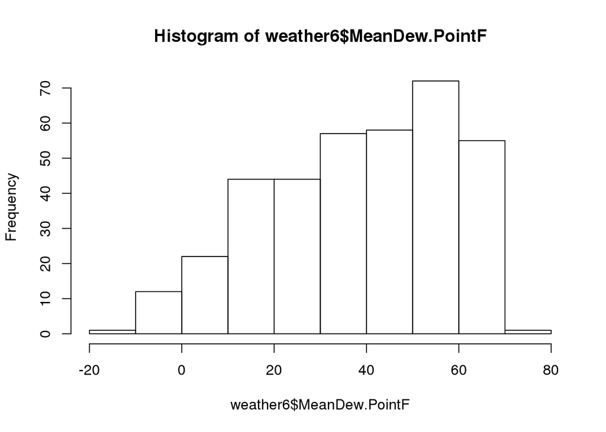

```r
# Look at histogram for MeanDew.PointF
hist(weather6$MeanDew.PointF)
```

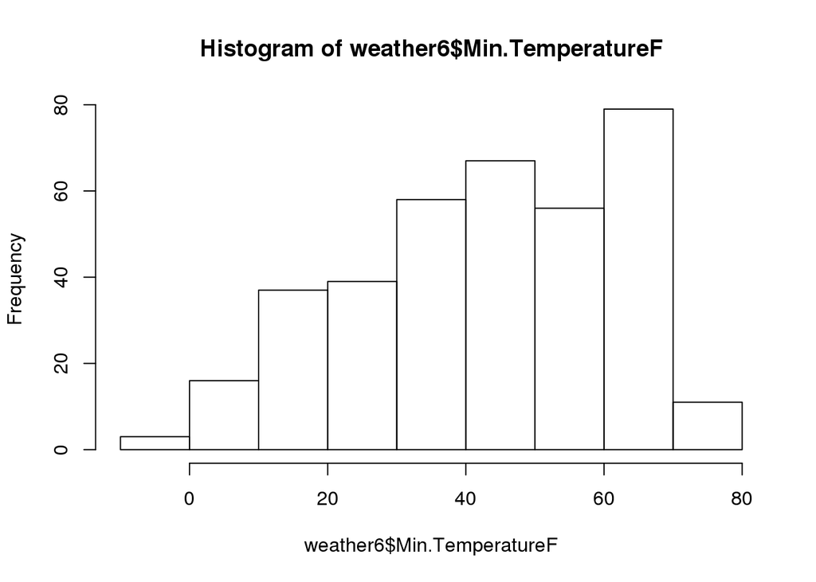

```r
# Look at histogram for Min.TemperatureF
hist(weather6$Min.TemperatureF)
```

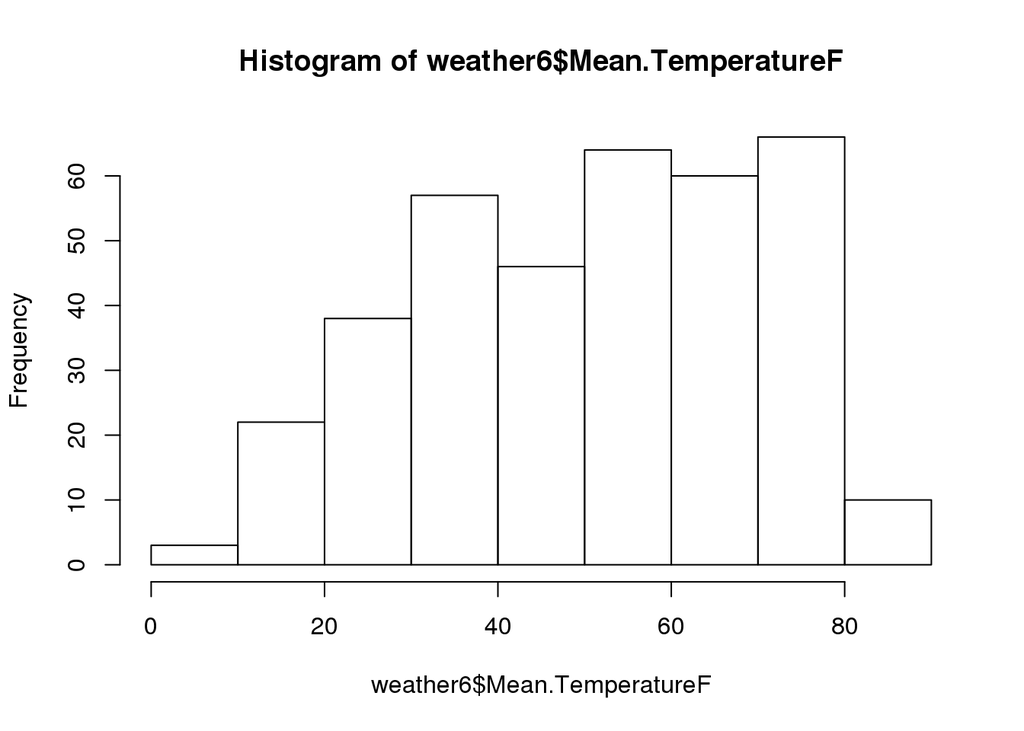

```r
# Compare to histogram for Mean.TemperatureF
hist(weather6$Mean.TemperatureF)
```

#### Finishing touches

Before officially calling our weather data clean, we want to put a couple of finishing touches on the data. These are a bit more subjective and may not be necessary for analysis, but they will make the data easier for others to interpret, which is generally a good thing.

There are a number of stylistic conventions in the R language. Depending on who you ask, these conventions may vary. Because the period (`.`) has special meaning in certain situations, we generally recommend using underscores (`_`) to separate words in variable names. We also prefer all lowercase latters son that no one has to remember which letters are uppercase or lowercase.

Finally, the `events` column (renamed to be all lowercase in the first instruction) contains an empty string (`""`) for any day on which there was no significant weather event such us rain, fog, a thunderstorm, etc. However, if it’s the first time you’re seeing these data, it may not be obvious that this is the case, so it’s best for us to be explicit and replace the empty strings with something more meaningful.

```r
# Clean up column names
names(weather6) <- tolower(names(weather6))
names(weather6) <- str_replace_all(names(weather6),"\\.","_")
# Replace empty cells in events column
weather6$events[weather6$events == ""] <- "None"

# Print the first 6 rows of weather6
head(weather6)
```

```
##         date    events cloudcover max_dew_pointf max_gust_speedmph
## 1 2014-12-01      Rain          6             46                29
## 2 2014-12-10      Rain          8             45                29
## 3 2014-12-11 Rain-Snow          8             37                28
## 4 2014-12-12      Snow          7             28                21
## 5 2014-12-13      None          5             28                23
## 6 2014-12-14      None          4             29                20
##   max_humidity max_sea_level_pressurein max_temperaturef
## 1           74                    30.45               64
## 2          100                    29.58               48
## 3           92                    29.81               39
## 4           85                    29.88               39
## 5           75                    29.86               42
## 6           82                    29.91               45
##   max_visibilitymiles max_wind_speedmph mean_humidity
```

[output cut: 34 more lines]